# ▒ 의사결정나무 ▒

## 0. 환경설정

```python
import os
import pandas as pd
import numpy as np
from functools import reduce
```

```python
# 시드 설정
np.random.seed(5)
```

## 1. 예제 데이터 불러오기

**[데이터 다운로드]**

- C드라이브에 [Python_project] 생성
- [Python_project] 하위폴더로 [DAT] 폴더 생성
- 데이터 스토어에서 샘플데이터(3.아파트_주소기반_주택지역특성시세정보_DB.xlsx)를 "C:/python_project/DAT/"에 다운로드  
  (https://www.datastore.or.kr/file/detail?id=2c0a9616-4d78-403c-9d77-3db2effb2a74&page=1&viewCount=10&sort=1&order=1&source=1&keyword=%EC%95%84%ED%8C%8C%ED%8A%B8)
- 서울/수도권 및 5대광역시 아파트에 대한 주소테이블 외 4개의 테이블(정보집단)로 구성되며 각각 주택특성정보, 지역특성정보, 가격/신뢰등급/예상회수율정보 테이블로 이루어져 있고, 각 테이블간은 고유키값(NUM)으로 연계되어 있음

**[데이터 호출]**

```python
dirFolder = 'C:/Users/Admin/Begas_Edu_Finacial_Preprocess/python_project/dat'
fileName = '3.아파트_주소기반_주택지역특성시세정보_DB.xlsx'

DF1 =pd.read_excel(os.path.join(dirFolder, fileName), sheet_name = 0)
DF2 =pd.read_excel(os.path.join(dirFolder, fileName), sheet_name = 1)
DF3 =pd.read_excel(os.path.join(dirFolder, fileName), sheet_name = 2)
DF4 =pd.read_excel(os.path.join(dirFolder, fileName), sheet_name = 3)

DF = reduce(lambda x,y: pd.merge(x,y) , [DF1, DF2, DF3, DF4])
DF['LAND_ACCESS'] = DF['LAND_ACCESS'].astype('float64')
```

```python
DF.shape
```

```
(500, 98)
```

```python
selectColL = ["SGG","PRICE_GEN", "FLOOR", "PRIV_AREA", "PUB_AREA",
              "SUM_AREA","UNIT_NUM","PARK_NUM", "LAND_ACCESS", "SUB_DIST"]
DF = DF[selectColL].dropna()
print(DF.shape)
```

```
(492, 10)
```

- SGG : 시군구
- PRICE_GEN ; 일반거래시세
- FLOOR : 층명
- PRIV_AREA : 전유면적
- PUB_AREA : 공유면적
- SUM_AREA : 계약 면적
- UNIT_NUM : 총세대수
- PARK_NUM : 총주차대수
- LAND_ACCESS : 개별공시지가
- SUB_DIST : 지하철역과의 거리

**[데이터 가공]** 데이터가 적은 지역 전처리 (광진구 제거, 종로구와 중구 통합)

```python
preDF = DF.loc[DF['SGG'] != '광진구']
preDF = preDF.reset_index(drop = True)
preDF.shape
```

```
(463, 10)
```

```python
preDF.loc[preDF['SGG'] == '성동구', 'SGG'] = 'A'
preDF.loc[preDF['SGG'] == '용산구', 'SGG'] = 'B'
preDF.loc[preDF['SGG'] == '종로구', 'SGG'] = 'C'
preDF.loc[preDF['SGG'] == '중구', 'SGG'] = 'C'
preDF.SGG.value_counts()
```

```
A    224
C    124
B    115
Name: SGG, dtype: int64
```

```python
preDF.head()
```

|  | SGG | PRICE_GEN | FLOOR | PRIV_AREA | PUB_AREA | SUM_AREA | UNIT_NUM | PARK_NUM | LAND_ACCESS | SUB_DIST |
| --- | --- | --- | --- | --- | --- | --- | --- | --- | --- | --- |
| 0 | C | 124000 | 14 | 126.34 | 88.60 | 214.94 | 1011.0 | 1480 | 8920000.0 | 501 |
| 1 | C | 131000 | 2 | 147.31 | 103.30 | 250.61 | 1011.0 | 1480 | 8920000.0 | 501 |
| 2 | C | 107000 | 14 | 94.51 | 66.27 | 160.78 | 1011.0 | 1480 | 8920000.0 | 501 |
| 3 | C | 70600 | 7 | 105.07 | 13.68 | 118.75 | 72.0 | 0 | 19000000.0 | 295 |
| 4 | C | 131000 | 6 | 140.78 | 100.84 | 241.62 | 462.0 | 0 | 14500000.0 | 422 |

**[데이터 분할]** Training set 70% , Test set 30% 무작위 추출을 이용하여 나누기

```python
rowNum = preDF.shape[0] #행 수
trainIdx = np.random.choice(rowNum, int(rowNum*0.7), replace = False).tolist()
testIdx  = [idx for idx in range(preDF.shape[0]) if idx not in trainIdx ]
```

```python
xColL = ['PRICE_GEN', 'FLOOR', 'PRIV_AREA', 'PUB_AREA', 'SUM_AREA',
       'UNIT_NUM', 'PARK_NUM', 'LAND_ACCESS', 'SUB_DIST']
xTrain = preDF.loc[trainIdx, xColL].to_numpy()
xTest  = preDF.loc[testIdx, xColL].to_numpy()
yTrain = preDF.loc[trainIdx, 'SGG'].to_numpy()
yTest  = preDF.loc[testIdx, 'SGG'].to_numpy()
```

```python
print(xTrain.shape, xTest.shape, yTrain.shape, yTest.shape)
```

```
(324, 9) (139, 9) (324,) (139,)
```

## 2. 의사결정나무

### 2.1 tree 생성 및 가지치기

**[기본 tree]**

```python
import sklearn
from sklearn.tree import DecisionTreeClassifier
from sklearn.tree import export_text, export_graphviz
import matplotlib.pyplot as plt
```

```python
treeMODEL = DecisionTreeClassifier(criterion = 'entropy',
                             max_depth = 10,
                             random_state = 0).fit(xTrain, yTrain)
```

```python
treeMODEL
```

```
DecisionTreeClassifier(ccp_alpha=0.0, class_weight=None, criterion='entropy',
                       max_depth=10, max_features=None, max_leaf_nodes=None,
                       min_impurity_decrease=0.0, min_impurity_split=None,
                       min_samples_leaf=1, min_samples_split=2,
                       min_weight_fraction_leaf=0.0, presort='deprecated',
                       random_state=0, splitter='best')
```

```python
r = export_text(treeMODEL, feature_names = xColL)
print(r)
```

```
|--- LAND_ACCESS <= 5294000.00
|   |--- UNIT_NUM <= 4399.50
|   |   |--- UNIT_NUM <= 194.50
|   |   |   |--- PUB_AREA <= 62.68
|   |   |   |   |--- PRIV_AREA <= 70.08
|   |   |   |   |   |--- PRIV_AREA <= 59.94
|   |   |   |   |   |   |--- PRICE_GEN <= 23550.00
|   |   |   |   |   |   |   |--- class: A
|   |   |   |   |   |   |--- PRICE_GEN >  23550.00
|   |   |   |   |   |   |   |--- PRICE_GEN <= 77400.00
|   |   |   |   |   |   |   |   |--- class: C
|   |   |   |   |   |   |   |--- PRICE_GEN >  77400.00
|   |   |   |   |   |   |   |   |--- class: A
|   |   |   |   |   |--- PRIV_AREA >  59.94
|   |   |   |   |   |   |--- class: C
|   |   |   |   |--- PRIV_AREA >  70.08
|   |   |   |   |   |--- class: A
|   |   |   |--- PUB_AREA >  62.68
|   |   |   |   |--- PARK_NUM <= 210.00
|   |   |   |   |   |--- SUB_DIST <= 786.50
|   |   |   |   |   |   |--- PRICE_GEN <= 93900.00
|   |   |   |   |   |   |   |--- class: C
|   |   |   |   |   |   |--- PRICE_GEN >  93900.00
|   |   |   |   |   |   |   |--- class: B
|   |   |   |   |   |--- SUB_DIST >  786.50
|   |   |   |   |   |   |--- class: A
|   |   |   |   |--- PARK_NUM >  210.00
|   |   |   |   |   |--- class: C
|   |   |--- UNIT_NUM >  194.50
|   |   |   |--- PRIV_AREA <= 58.44
|   |   |   |   |--- PRIV_AREA <= 53.60
|   |   |   |   |   |--- class: A
|   |   |   |   |--- PRIV_AREA >  53.60
|   |   |   |   |   |--- class: C
|   |   |   |--- PRIV_AREA >  58.44
|   |   |   |   |--- SUB_DIST <= 301.50
|   |   |   |   |   |--- SUB_DIST <= 239.00
|   |   |   |   |   |   |--- PUB_AREA <= 41.42
|   |   |   |   |   |   |   |--- PUB_AREA <= 28.48
|   |   |   |   |   |   |   |   |--- class: A
```

[output cut: 72 more lines]

```
|   |   |   |   |   |   |   |   |   |--- SUB_DIST <= 500.00
|   |   |   |   |   |   |   |   |   |   |--- class: B
|   |   |   |   |   |   |   |   |   |--- SUB_DIST >  500.00
|   |   |   |   |   |   |   |   |   |   |--- class: C
|   |   |   |   |   |   |   |--- PRIV_AREA >  126.32
|   |   |   |   |   |   |   |   |--- class: C
|   |   |   |   |   |--- UNIT_NUM >  1664.00
|   |   |   |   |   |   |--- class: C
|   |   |   |--- PRICE_GEN >  170000.00
|   |   |   |   |--- LAND_ACCESS <= 14720000.00
|   |   |   |   |   |--- class: B
|   |   |   |   |--- LAND_ACCESS >  14720000.00
|   |   |   |   |   |--- class: A
|   |--- SUB_DIST >  681.00
|   |   |--- class: B
```

**[시각화]**

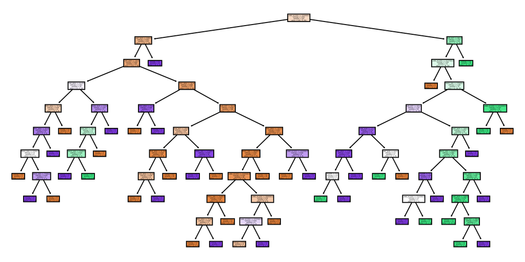

```python
fig, axes = plt.subplots(nrows = 1, ncols = 1, figsize = (10,5), dpi = 300)
plotResult = sklearn.tree.plot_tree(treeMODEL,
                                    feature_names = xColL,
                                   filled = True)
```

**[가지치기]**노드수 활용

```python
tree_prune = DecisionTreeClassifier(criterion = 'entropy',
                             max_depth = 5,
                             random_state = 0).fit(xTrain, yTrain)
tree_prune.fit = tree_prune.fit(xTrain, yTrain)
```

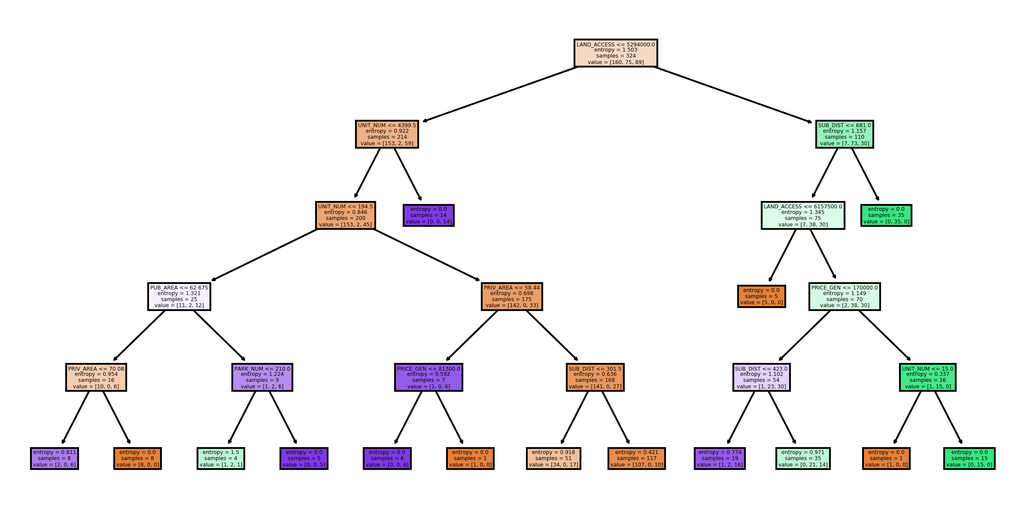

```python
fig, axes = plt.subplots(nrows = 1, ncols = 1, figsize = (10,5), dpi = 300)
plotResult = sklearn.tree.plot_tree(tree_prune,
                                    feature_names = xColL,
                                   filled = True)
```

**[예측]** tree예측

```python
predY = tree_prune.predict(xTest)
predY
```

```
array(['C', 'B', 'B', 'C', 'C', 'C', 'A', 'A', 'A', 'A', 'A', 'B', 'C',
       'A', 'C', 'C', 'A', 'A', 'A', 'A', 'C', 'A', 'A', 'A', 'C', 'C',
       'C', 'A', 'A', 'C', 'C', 'B', 'B', 'B', 'B', 'B', 'B', 'B', 'C',
       'B', 'B', 'B', 'B', 'B', 'C', 'B', 'B', 'B', 'B', 'B', 'B', 'B',
       'B', 'B', 'B', 'B', 'B', 'B', 'C', 'C', 'C', 'C', 'B', 'B', 'B',
       'B', 'B', 'B', 'B', 'B', 'C', 'B', 'B', 'B', 'B', 'A', 'A', 'A',
       'A', 'A', 'A', 'A', 'C', 'A', 'A', 'A', 'A', 'A', 'A', 'A', 'A',
       'A', 'A', 'A', 'A', 'A', 'A', 'A', 'A', 'A', 'A', 'A', 'A', 'A',
       'A', 'A', 'A', 'A', 'A', 'A', 'A', 'A', 'A', 'A', 'C', 'A', 'A',
       'A', 'A', 'A', 'A', 'A', 'A', 'A', 'A', 'A', 'A', 'A', 'A', 'A',
       'A', 'A', 'A', 'C', 'C', 'B', 'B', 'A', 'A'], dtype=object)
```

**[예측]** 오분류율

```python
print('[오분류율] : ', round((1 - tree_prune.score(xTest, yTest))*100, 3) ,' %')
```

```
[오분류율] :  25.18  %
```